# Homework 09

## DATA 1010

## Fall 2020

## Problem 1

If we fit a kernelized SVM model using LIBSVM, then it produces a collection of values that can be used to compute the decision function (essential the prediction function, but just before we apply the signum function):

```julia
using Pkg; Pkg.activate("MLJ", shared=true)
Pkg.add("MLJ")
Pkg.add("MLJScikitLearnInterface")
```

```
 Activating environment at `~/.julia/environments/MLJ/Project.toml`
   Updating registry at `~/.julia/registries/General`
######################################################################### 100.0%
  Resolving package versions...
No Changes to `~/.julia/environments/MLJ/Project.toml`
No Changes to `~/.julia/environments/MLJ/Manifest.toml`
  Resolving package versions...
No Changes to `~/.julia/environments/MLJ/Project.toml`
No Changes to `~/.julia/environments/MLJ/Manifest.toml`
```

```julia
using MLJ, Plots
```

```julia
using Random; Random.seed!(123)
X, y = make_moons(noise = 1/4)
scatter(X.x1, X.x2, group = y, color = [:blue :red], label = "")
```

[figure not shown]

```julia
model = @load SVMClassifier
model.kernel = "rbf"
svm = machine(model, X, y)
fit!(svm)
```

```
┌ Info: Precompiling MLJScikitLearnInterface [5ae90465-5518-4432-b9d2-8a1def2f0cab]
└ @ Base loading.jl:1278
┌ Info: Training Machine{SVMClassifier} @953.
└ @ MLJBase /home/enminz/.julia/packages/MLJBase/xg2Ti/src/machines.jl:319
```

```
Machine{SVMClassifier} @953 trained 1 time.
  args:
    1:	Source @845 ⏎ `Table{AbstractArray{Continuous,1}}`
    2:	Source @574 ⏎ `AbstractArray{Multiclass{2},1}`
```

```julia
fitted_params(svm)
```

```
(support = Int32[27, 33, 41, 43, 50, 52, 55, 58, 65, 79  …  108, 109, 110, 125, 132, 135, 137, 140, 142, 148],
 support_vectors = [0.4839195070201942 0.3987849338861288; -1.10041255494672 0.008576762121766862; … ; 0.06405257812100115 0.0017672298035346923; -0.6801894138042015 0.17639266603252177],
 n_support = Int32[24, 25],
 dual_coef = [-1.0 -0.693755862643101 … 1.0 1.0],
 coef = nothing,
 intercept = [0.08985912448735472],
 fit_status = 0,
 classes = UInt32[0x00000001, 0x00000002],)
```

The `dual_coef` values correspond to what we're calling $\eta$ in the math notation. However, note that only the nonzero $\eta$ values are stored! To see which ones are nonzero, look at `support`. The `support_vectors` are also included, for your convenience. What we've been calling $\alpha$ corresponds to `intercept`.

Write some code which uses these values to compute the decision function (that is, from scratch, not using `_decision_function` as we did in class), and use it to plot a heatmap of the decision function. You might have to include the radial basis function manually, since that's actually hard-coded in LIBSVM.

Notes:  
(1) the course cheatsheet describes the prediction function exactly.  
(2) the knowledge you gain in this question is not Julia-specific; LIBSVM is the main library underlying SVM packages in various dynamic languages.

```julia
support, support_vectors, n_support, dual_coef, coef, intercept, fit_status, classes = fitted_params(svm)
```

```
(support = Int32[27, 33, 41, 43, 50, 52, 55, 58, 65, 79  …  108, 109, 110, 125, 132, 135, 137, 140, 142, 148],
 support_vectors = [0.4839195070201942 0.3987849338861288; -1.10041255494672 0.008576762121766862; … ; 0.06405257812100115 0.0017672298035346923; -0.6801894138042015 0.17639266603252177],
 n_support = Int32[24, 25],
 dual_coef = [-1.0 -0.693755862643101 … 1.0 1.0],
 coef = nothing,
 intercept = [0.08985912448735472],
 fit_status = 0,
 classes = UInt32[0x00000001, 0x00000002],)
```

```julia
using LinearAlgebra
rbf_kernel(a,b;γ=1) = exp(-γ*sum((a.-b).^2));
y_nonzero = [y[i] for i in support]
# n = zeros(length(y))
# index = 1
# for i in support
#     n[i] = dual_coef[index]
#     index += 1
# end
int_y = [if i==1 1 else -1 end for i in y]
# new_X = [[X[1][i], X[2][i]] for i = 1:150]
# beta = new_X' * (n .* int_y)
function predict(x)
    k = sum([rbf_kernel(x, [support_vectors[i,1], support_vectors[i,2]])*dual_coef[i] for i in 1:length(y_nonzero)])
    res = k .+ intercept[1]
    return res[1]
end
```

```
predict (generic function with 2 methods)
```

```julia
using Statistics, LinearAlgebra, Distributions, Plots, JuMP, Ipopt, Contour
# include("contourplot.jl");
function visualize(signum = true)
    zone(x) = x < -1 ? 1 : (x < 0 ? 2 : (x < 1 ? 3 : 4))
    xmin, xmax = extrema([i[1] for i in new_X])
    ymin, ymax = extrema([i[2] for i in new_X])
    xrange = xmax - xmin
    xmax += 0.25*xrange
    xmin -= 0.25*xrange
    yrange = ymax - ymin
    ymax += 0.25*yrange
    ymin -= 0.25*yrange
    xs = range(xmin, stop = xmax, length=512)
    ys = range(ymin, stop = ymax, length=512)
    Plots.heatmap(xs, ys, (x,y) -> zone(predict([x,y])),
            fillopacity = 0.5, colorbar = false, fontfamily = "Palatino",
            fillcolor = cgrad([:blue, :lightblue, :pink, :red]), aspect_ratio = 1, size = (400, 400))
    reds = new_X[int_y .== 1]
    blues = new_X[int_y .== -1]
#     contourplot!(xs, ys, (x,y) -> predict([x,y]), [-1,0,1], color = :black, linewidth = 0.5)
    scatter!([i[1] for i in reds], [i[2] for i in reds], color = :red, label = "", ms = 2, opacity = 0.5)
    scatter!([i[1] for i in blues], [i[2] for i in blues], color = :blue, label = "", ms = 2, opacity = 0.5)
end
```

```
visualize (generic function with 2 methods)
```

```julia
visualize()
```

[figure not shown]

## Problem 2

Apply the Lagrange duality method we apply in Data Gymnasia to obtain the dual SVM to the problem of minimizing the objective function $f(x,y) = x^2 + y^2$ subject to the constraint $x + y \ge 5$. Show that strong duality holds (that is, we get the same value for the objective function if we swap min and max).

Note: this problem is asking you to walk through the same steps: introducing the function $H$, swapping min/max, etc. The only difference is that you're dealing with a much simpler optimization problem.

The constraint is $x+y \geq 5$, which is $5-x-y \leq 0$. We define a function H(x) so that when $x \leq 0$, H(x) = 0 and when H(x) = $\inf$ otherwise.

So our optimization problem is equivalent to $x^2 + y^2 + H(5 - x - y)$, since when the constraint is not satified, H term will return infinity and the problem will not be minimized.

Let H(x) be $u*x$, the Lagrangian is L(x,u) = $x^2+y^2+u(5-x-y)$, and the lagrangian dual function is $\theta(u)$ = min{$x^2+y^2+u(5-x-y)$} = 5u + min{$x^2+y^2-ux-uy$} = 5u + min{$x^2-ux$}+min{$y^2-uy$}

For a fixed value $u \geq 0$, the minimum of L(x,u) is attained at x = y = $\frac{u}{2}$ and L(x,u) = $5u - \frac{u^2}{2}$.

The dual function is concave and differentiable, so the strong duality holds and the optimal objective function values are equal. We want to maximize the value of the dual function: $\frac{dL}{du} = 5-u = 0$

Therefore, x(u*) = 2.5 and y(u*) = 2.5 and the minimized f(x,y) = 12.5

## Problem 3

Let's take a look at the zeros and ones in the MNIST dataset:

```julia
Pkg.add("MLDatasets")
using MLDatasets
```

```
  Resolving package versions...
No Changes to `~/.julia/environments/MLJ/Project.toml`
No Changes to `~/.julia/environments/MLJ/Manifest.toml`
```

```julia
function load_MNIST_zeros_and_ones()
    features, labels = MNIST.traindata()
    features = reshape(features[:, :, labels .∈ Ref((0, 1))], (28^2, :))
    labels = labels[labels .∈ Ref((0,1))];
    float(features), labels
end
```

```
load_MNIST_zeros_and_ones (generic function with 1 method)
```

```julia
features, labels = load_MNIST_zeros_and_ones()
```

[output not shown]

```
(Float32[0.0 0.0 … 0.0 0.0; 0.0 0.0 … 0.0 0.0; … ; 0.0 0.0 … 0.0 0.0; 0.0 0.0 … 0.0 0.0], [0, 1, 1, 1, 1, 0, 1, 1, 0, 0  …  0, 0, 1, 1, 1, 0, 1, 1, 0, 1])
```

Each column of `features` stores the pixel intensities for a 28 by 28 image:

```julia
size(features)
```

```
(784, 12665)
```

We can see these images by reshaping each column back into a 28 by 28 image and converting the intensity to an actual color value:

```julia
hcat([Gray.(reshape(features[:, k], 28, 28)') for k in 1:10]...)
```

[figure not shown]

Would you guess that there exists a hyperplane in the 784-dimensional space in which the digits live which perfectly separates all the zeros from the ones?

Make a conjecture first and then figure out the truth computationally.

(Sol) My conjecture is that it is separable because the dimensional space is high and there is a clear difference between the pattern of '1's and pattern of '0's in certain dimensions.

```julia
import LIBSVM
```

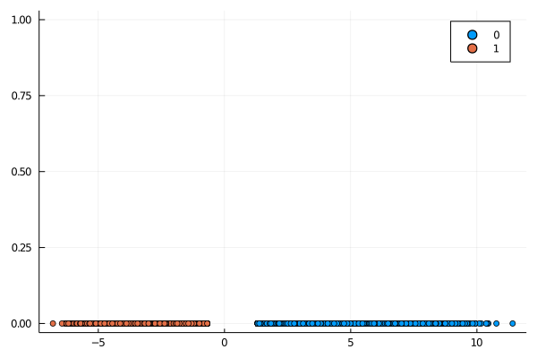

```julia
model = LIBSVM.svmtrain(float(features), float(labels), kernel = LIBSVM.Kernel.Linear, cost = 100.0);
β = model.SVs.X * model.coefs
gr(fmt=:png)
scatter(features' * β .- [1], zeros(size(features,2)), group = labels, legend = true)
```

```julia
class = [if i < 0 1 else 0 end for i in sign.(features' * β .- [1])]
sum(class .== labels)/length(labels)
```

```
1.0
```

The output shows that the 784-dimension vector is mapped to a certain value that are clearly separable by a hyperplane and we have a prediction accuracy of 1.0.